# Advanced R: Rmarkdown and Tidyverse

2022-01-19

## Todays plan

- While we are at it: tidyverse, while you are fresh and rested ;)
- Rmarkdown and manuscript writing

## Tidyverse

## Why tidyverse

- Cleaner code
- Useful automatisation
- Great data processing language
- Coherent structure of packages

## Why *not* tidyverse

- Changes the logic of the language
- Makes your code depend on tidyverse
- Fewer people will understand your code
- Easy things are even easier, hard things are even harder
- Useful mostly for data frames and lists (but that’s not entirely true)
- quickly evolving: all the time new functionality replaces old functionality

## My take

- When writing published packages, I try to avoid tidyverse. I rather re-implement the functionality then make my package depend on tidyverse.
- (and never make the package dependent on the `tidyverse` meta-package)
- If absolutely necessary, I import single packages and single functions
- I use tidyverse ad lib when writing reports and manuscripts (so basically in Rmarkdown)

## My god, it’s full of packages

## Tidyverse overview

[figure not shown]

## Tidyverse packages

| Package | What does it do | What does it replace / introduce |
| --- | --- | --- |
| rlang | Main tidyverse framework, a redefinition of R | A lot of base R constructs; introduces quosures |
| tibble | New model of data frames | data frames |
| dplyr | Main data frame manipulation tool | data frame operations |
| tidyr | Manipulating data formats, pivoting | e.g. reshape & co |
| magrittr | Introducing pipes to R | The `%>%` operator & co |
| purrr | Functional constructs | lapply, sapply & co |
| readr | read and write data frames | read.table & co |
| forcats | dealing with factors | introduces goodies for working with factors |
| stringr | dealing with strings | introduces goodies for working with strings |
| broom | standardizing output of common functions | `summary()` |
| ggplot2 | Graphics based on “Grammar of graphics” | replaces base plotting utilities |

## How to use tidyverse

- load with `library(tidyverse)`
- some packages (e.g. `magrittr`) need to be loaded separately
- never load `plyr` after `dplyr`. In fact, do not use `plyr`

## Introducing tibbles

## Data frames are lists

Since we are talking about data frames, did you notice that a data frame *is a list*?

```r
is.list(data.frame(ID=1))
```

```
## [1] TRUE
```

- data frames look like matrices, but are not matrices!
- they are a special type of list

## The problem with data frames

- It makes (mathematical) sense that a column or row of a matrix is not a matrix, but a vector, since one-dimensional matrix is a vector
- however, `df[,1]` is a vector, but `df[1,]` is not (and cannot be! why?)
- data frames (and base R data frame operations) have nasty habits of modifying your data: changing column names, turning columns into factors etc.

## So many ways to skin a cat

data.frame has so many problems. Luckily, there are also so many solutions.

- data.table / DT
- DataFrame (BioConductor)
- colorDF ;-)
- tibble (tidyverse, formerly known as data_frame)
- special objects (ExpressionSet, limma/edgeR objects etc.)

## What is special about tibble

- Hadley Wickham hates row names (and he has reasons)
- tbl[,3] returns a tbl rather than a vector
- nicer printing (but… colorDF is WAY better ;-))
- extra properties (`group_by` etc.)
- can give major headache when used in connection with Bioconductor

## Fine, but…

If you want to view more than the default portion of the tibble, do

```r
print(starwars, n=Inf, width=Inf)
```

Row names: convert them to a column with `rownames_to_column`, use filter() instead of `[`

## Reading data with readr

- read_{tsv,csv,…}, write…
- better, cleaner, faster
- explicit
- will never turn a string into a factor

## Reading data

| Data type | Function | Tidyverse | Notes |
| --- | --- | --- | --- |
| TSV / TAB separated values | `read.table()` | `read_tsv()`, `read_delim()` | Tab is `\t`. A very general and customizable function |
| CSV / comma separated | `read.csv()`, | `read_csv()`, `read_delim()` | a wrapper around `read.table()` |
| XLS (old Excel) |  | `read_xls()`, `read_excel()` | Avoid old Excel format! From the `readxl` package. |
| XLSX (new Excel) |  | `read_xlsx()`, `read_excel()` | From the `readxl` package. You need to provide the sheet number you wish to read. Note: returns a tibble, not a data frame! |

## Exercise session 2/1

## Introducing Pipes

Remember? In R, almost everything is a function, but some functions are special: they look like operators.

```r
vec <- 1:10
`[`(vec, 2)
```

```
## [1] 2
```

```r
`+`(1, 2)
```

```
## [1] 3
```

## Introducing Pipes

It is possible to create your own functions which work like operators.

```r
`%cup%` <- function(x, y) union(x, y)
1:10 %cup% 2:15
```

```
##  [1]  1  2  3  4  5  6  7  8  9 10 11 12 13 14 15
```

```r
`%cap%` <- function(x, y) intersect(x, y)
1:10 %cap% 2:15
```

```
## [1]  2  3  4  5  6  7  8  9 10
```

The names for the operators here come from the \(\LaTeX\) symbol names for mathematical set operators \(\cup\) (“cup”) and \(\cap\) (“cap”).

## Simple beginner pipe

```r
`%=>%` <- function(a, func) {
  func(a)
}

mtcars %=>% head
```

```
##                    mpg cyl disp  hp drat    wt  qsec vs am gear carb
## Mazda RX4         21.0   6  160 110 3.90 2.620 16.46  0  1    4    4
## Mazda RX4 Wag     21.0   6  160 110 3.90 2.875 17.02  0  1    4    4
## Datsun 710        22.8   4  108  93 3.85 2.320 18.61  1  1    4    1
## Hornet 4 Drive    21.4   6  258 110 3.08 3.215 19.44  1  0    3    1
## Hornet Sportabout 18.7   8  360 175 3.15 3.440 17.02  0  0    3    2
## Valiant           18.1   6  225 105 2.76 3.460 20.22  1  0    3    1
```

```r
## same as head(mtcars)
```

## Introducing Pipes

How about an operator that calls just any function?

```r
a %>% some_func(b)

## is the same as

`%>%`(a, some_func(b))

## which then (with magic) becomes
some_func(a, b)
```

If you want to know more about this magic, read [Advanced R](http://adv-r.had.co.nz/) by Hadley Wickham. Not an easy read, though.

## Introducing Pipes

Pipes work for *anything*, not just the tidyverse!

```r
df <- data.frame(1:1000)

df %>% head
```

```
##   X1.1000
## 1       1
## 2       2
## 3       3
## 4       4
## 5       5
## 6       6
```

## Pipes in full: magrittr package

## Ceci n’est pas une pipe

Magrittr defines a number of aliases – and of course the pipe operator, `%>%`. However, there is more to this package.

- aliases (extract, set_names etc.)
- `%$%` operator (pipe version of `attach`)
- `%<>%` operator (instant assignment)

## Simplified function notation

OK, so you remember than in the following

```r
func <- function(.) { paste("Hello, ", .) }
func("Dolly")
```

```
## [1] "Hello,  Dolly"
```

`func` is a variable holding a function; the actual function is the thing on the right. Also, dot is a simple variable name, just like `foo` or `size`.

## Passing anonymous functions as arguments

The following are equivalent:

```r
func <- function(.) { paste("Hello, ", .) }
some_other_function(arguments, func)
some_other_function(arguments, function(.) { paste("Hello, ", .) })

## no need for braces with only one statement
some_other_function(arguments, function(.) paste("Hello, ", .))
```

## Passing anonymous functions as arguments

Programmers are lazy. Tired of writing `function(.) { ... }` they came up with a shorthand notation:

```r
some_other_function(arguments, ~ paste("Hello, ", .))
```

Here, the tilde (`~`) is the same as `function(.)`. That’s it, no magic other than that. (almost no magic, sometimes the number of arguments is larger than 1, we will come to that later).

We can only use it in tidyverse!!

## dplyr

## dplyr: managing data

- select, mutate, filter, rename, pull, arrange, all_of, everything
- distinct, sample_{n,frac}, add_count, add_tally
- summarise, across, where
- group_by

(Demo)

## select

Select columns from data:

```
starwars %>% select(name)
mtcars %>% select(mpg, Cylinder=cyl)
mtcars %>% select(starts_with("d"))
mtcars %>% select(everything())
starwars %>% select(name:mass)
starwars %>% select(where(is.numeric))
```

## Selecting in tidyverse

Note that we are not using quotes around the column names. These are so called *data variables*. In base R, we can also do something like this:

```r
# instead of starwars$name
with(starwars, paste("Name:", name))
```

## mutate

Create new columns

```
mtcars %>% mutate(lp100km=282.5/mpg)
```

## filter

Select rows from the data

```
mtcars %>% filter(hp > 100)
mtcars %>% filter(hp > 100 & cyl < 8)
```

## pull

Get a single column as a vector

```
mtcars %>% pull(mpg)
```

## arrange

Sort the rows of the data

```r
mtcars %>% arrange(mpg)
```

## Exercise Session 2/2

## Grouping in dplyr

## `group_by`

`group_by` introduces a grouping in a data frame that can be then used by `summarise` to calculate something reasonable. This is a lot like `tapply`.

```r
mtcars %>% group_by(cyl) %>%
  summarise(m.hp=mean(hp))
```

## `group_by`

This has the advantage that you can define a whole range of calculations based on any column in the data:

```r
mtcars %>% group_by(cyl) %>%
  summarise(m.hp=mean(hp), m.wt=mean(wt))
```

Or you can use a more complex function:

```r
## which planet has the largest mean BMI?
starwars %>% group_by(homeworld) %>%
  summarise(bmi = mean(mass/(height/100)^2)) %>%
  arrange(bmi)
```

## Weird, weird world (heavy stuff)

What if we don’t want to choose a variable by hand?

```r
## note: mean is now an argument to across!!!
mtcars %>% group_by(cyl) %>% summarise(across(everything(), mean))
```

```
## # A tibble: 3 × 11
##     cyl   mpg  disp    hp  drat    wt  qsec    vs    am  gear  carb
##   <dbl> <dbl> <dbl> <dbl> <dbl> <dbl> <dbl> <dbl> <dbl> <dbl> <dbl>
## 1     4  26.7  105.  82.6  4.07  2.29  19.1 0.909 0.727  4.09  1.55
## 2     6  19.7  183. 122.   3.59  3.12  18.0 0.571 0.429  3.86  3.43
## 3     8  15.1  353. 209.   3.23  4.00  16.8 0     0.143  3.29  3.5
```

## Weird, weird world (heavy stuff)

Or, if we want something more complex, we use the `~ ...` form:

```r
mtcars %>% group_by(cyl) %>% summarise(across(everything(), ~ mean(.)/sd(.)))
```

```
## # A tibble: 3 × 11
##     cyl   mpg  disp    hp  drat    wt  qsec     vs    am  gear  carb
##   <dbl> <dbl> <dbl> <dbl> <dbl> <dbl> <dbl>  <dbl> <dbl> <dbl> <dbl>
## 1     4  5.91  3.91  3.95 11.1   4.01  11.4   3.02 1.56   7.58  2.96
## 2     6 13.6   4.41  5.04  7.53  8.75  10.5   1.07 0.802  5.59  1.89
## 3     8  5.90  5.21  4.10  8.67  5.27  14.0 NaN    0.393  4.52  2.25
```

The dot (`.`) stands for the argument. (remember? dot is just a normal character, it can be a variable name!)

## Even more heavy stuff

```r
starwars %>% summarise(across(where(is.numeric), mean))
```

```
## # A tibble: 1 × 3
##   height  mass birth_year
##    <dbl> <dbl>      <dbl>
## 1     NA    NA         NA
```

```r
starwars %>% summarise(across(where(is.numeric), ~ mean(., na.rm=T)))
```

```
## # A tibble: 1 × 3
##   height  mass birth_year
##    <dbl> <dbl>      <dbl>
## 1   174.  97.3       87.6
```

## ….aaaaaand some more

```r
starwars %>%
  summarise(across(where(~ is.numeric(.) & sum(is.na(.)) < 10), ~ mean(., na.rm=T)))
```

```
## # A tibble: 1 × 1
##   height
##    <dbl>
## 1   174.
```

- where takes a function as an argument, so instead of the variable holding a function we can use an anonymous function. It allows selecting the variables for which this function gives a TRUE value
- across takes two arguments; first is a column selection (where, all_of, everything etc.); second is a function.

## Exercise Session 2/3

## Wide and Long data format

## Wide and Long format

Long (stacked, tall, narrow) advantages:

- easier to filter, process, visualize, do statistics with
- focused on measurement (“patient ID” or equivalent is a covariate, and so is measurement type)

Wide (un-stacked) advantages:

- groups data by a covariate (“patient ID”)
- can be easier to manage (each column one measurement type)
- can be more compact

## Long vs wide data

`pivot_longer()`, `pivot_wider()`

## Converting from wide to long:

```r
wide <- read.table(header=TRUE, text='
 subject sex control cond1 cond2
       1   M     7.9  12.3  10.7
       2   F     6.3  10.6  11.1
       3   F     9.5  13.1  13.8
       4   M    11.5  13.4  12.9
')
pivot_longer(wide, control:cond2, names_to="key",
             values_to="measurement")
```

## Converting from wide to long:

```r
wide <- read.table(header=TRUE, text='
 subject sex control cond1 cond2
       1   M     7.9  12.3  10.7
       2   F     6.3  10.6  11.1
       3   F     9.5  13.1  13.8
       4   M    11.5  13.4  12.9
')
pivot_longer(wide, control:cond2, names_to="key",
             values_to="measurement")
```

```
## # A tibble: 12 × 4
##    subject sex   key     measurement
##      <int> <chr> <chr>         <dbl>
##  1       1 M     control         7.9
##  2       1 M     cond1          12.3
##  3       1 M     cond2          10.7
##  4       2 F     control         6.3
##  5       2 F     cond1          10.6
##  6       2 F     cond2          11.1
##  7       3 F     control         9.5
##  8       3 F     cond1          13.1
##  9       3 F     cond2          13.8
## 10       4 M     control        11.5
## 11       4 M     cond1          13.4
## 12       4 M     cond2          12.9
```

## Converting from long to wide

```r
long <- read.table(header=TRUE, text='
 subject  sampleID sex condition measurement
       1  ID000001 M   control         7.9
       1  ID000002 M     cond1        12.3
       1  ID000003 M     cond2        10.7
       2  ID000004 F   control         6.3
       2  ID000005 F     cond1        10.6
       2  ID000006 F     cond2        11.1
       3  ID000007 F   control         9.5
       3  ID000008 F     cond1        13.1
       3  ID000009 F     cond2        13.8
')
```

## Converting from long to wide

```r
## not what we wanted!!!
pivot_wider(long, names_from="condition", values_from="measurement")
```

```
## # A tibble: 9 × 6
##   subject sampleID sex   control cond1 cond2
##     <int> <chr>    <chr>   <dbl> <dbl> <dbl>
## 1       1 ID000001 M         7.9  NA    NA
## 2       1 ID000002 M        NA    12.3  NA
## 3       1 ID000003 M        NA    NA    10.7
## 4       2 ID000004 F         6.3  NA    NA
## 5       2 ID000005 F        NA    10.6  NA
## 6       2 ID000006 F        NA    NA    11.1
## 7       3 ID000007 F         9.5  NA    NA
## 8       3 ID000008 F        NA    13.1  NA
## 9       3 ID000009 F        NA    NA    13.8
```

What happened: all three remaining cols (subject, sampleID and sex) were used *together* as an identifier. Since sampleID is unique for each row, for sampleID ID000001 we only have a value for control, but no value for cond1 and cond2. Thus, we got a table with as many rows as in the long format, with plenty of NA’s!

## Converting from long to wide

```r
## Instead:
pivot_wider(long, id_cols=subject, names_from="condition", values_from="measurement")
```

```
## # A tibble: 3 × 4
##   subject control cond1 cond2
##     <int>   <dbl> <dbl> <dbl>
## 1       1     7.9  12.3  10.7
## 2       2     6.3  10.6  11.1
## 3       3     9.5  13.1  13.8
```

## Long vs wide data: which one to choose?

- What is the target of the data?
  - analysis, storage, data exchange: long format
  - results presentation, overview: wide format (possibly)
- What is the unit of observation?
  - one unit = one row

## group_by

Essentially, add information to the tibble that the data is grouped by a variable. This does not change the actual data!

```r
identical(table2, table2 %>% group_by(country))
```

```
## [1] FALSE
```

```r
identical(as.data.frame(table2),
          as.data.frame(table2 %>% group_by(country)))
```

```
## [1] TRUE
```

You can then use several other functions.

## Use with caution!

While tidyverse is great for interactive work, you should use it with caution in your functions:

```r
foo <- function(df) {
  cols <- c("sex", "age")
  df <- df %>% select(cols)

  # ... do something

  return(df)
}
```

What happens when df contains `cols`?

## Solution

Be wary of tidyverse shortcuts. Always assume the worst case scenario and be explicit in your code:

```r
# make sure you select columns from variable
# and not by name
df <- df %>% select(all_of(cols))

# or, to use all but the columns in cols
df <- df %>% select(!all_of(cols))
```

## Of mice and men

## Of mice and men

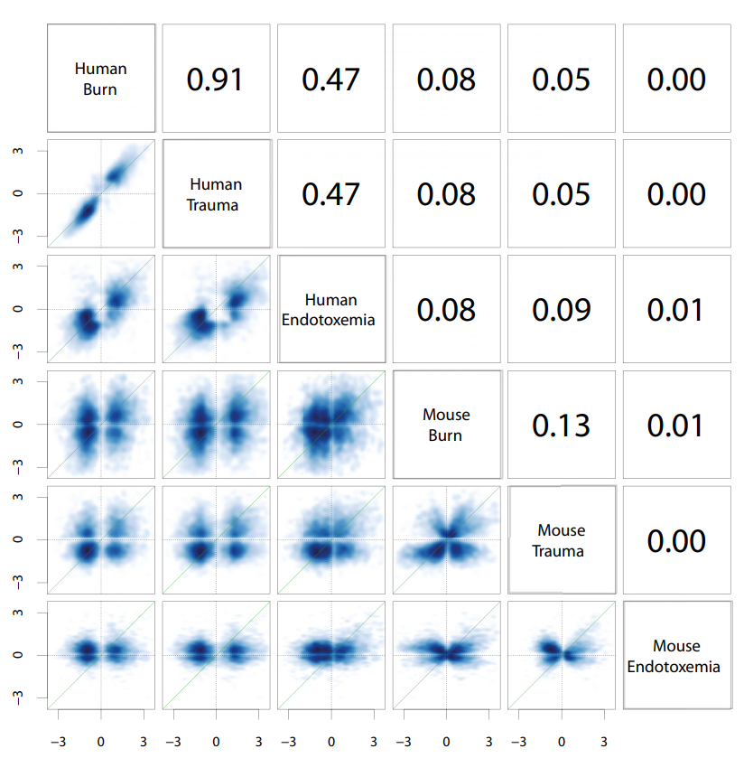

- No or little correlation between transcriptomic responses in mouse models and human models: \(r^2 < 0.1\) – less than 10% of variance explained
- No similarity in identified functions

## Of mice and men

[figure not shown]

## Of mice and men

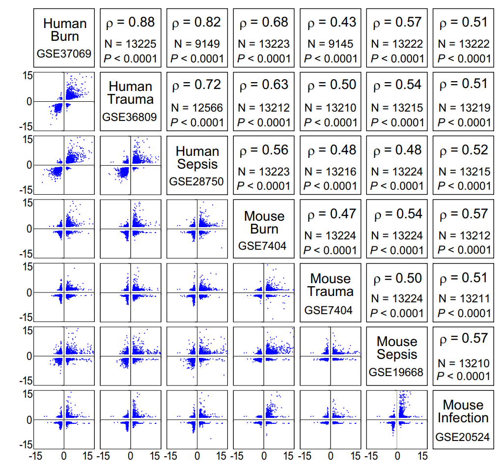

## Reproducibility, Repeatability, Replicability

- **Repeatability:** you can repeat your calculations precisely
- **Replicability:** Others can repeat your calculations precisely.
- **Reproducibility:** Other approaches to the same problem give compatible results.

*McArthur SL. Repeatability, Reproducibility, and Replicability: Tackling the 3R challenge in biointerface science and engineering.*

## Of mice and men

[figure not shown]

- None of the papers was replicable, because precise description of methods leading from data to results was missing.
- At best, we were able to *roughly* reproduce the results using guesswork and custom code

## (R)markdown

## markdown

Markdown is a markup language: a way of indicating to the computers which parts of our text mean what, e.g. what is a header, what is a bullet list etc. Markdown is very, very simple and easy to read even when you are human (unlike XML or HTML).

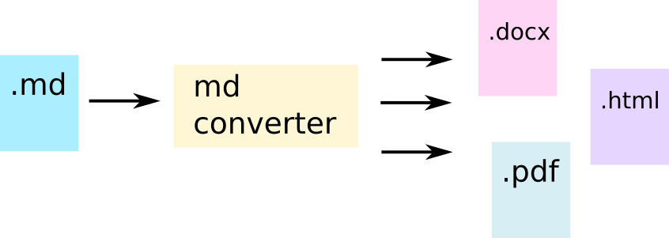

## Markdown basics

- Headers: `#`, `##`, `###`…
- *italic* `*italic*` or `_italic_`
- **bold** `**bold**` or `__bold__`
- bullet lists: start with `*` (space before!)
- numbered lists: start with `2.` (space before!)
- Superscript: a<sup>2</sup> `a^2^`, subscript: a<sub>2</sub> `a~2~`

## So much more

- tables (you can produce them in R with `kable` or `pander`)
- code: demarkated using backticks (`` ` ``, `` ``` ``)
- references: need a BibTeX file (you can get it from google scholar!)
- images: `![my_portrait](portrait.jpeg)`
- mathematical notations: \(\chi^2 \sim - 2 \times \log\sum_{i=1}^k p_i\)

\[X = \begin{bmatrix}1 & x_{1}\\ 1 & x_{2}\\ 1 & x_{3} \end{bmatrix}\]

## Rmarkdown

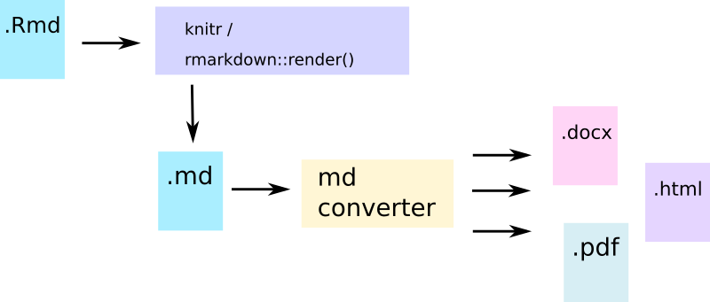

## Using R in markdown for fun and profit

Chunks:

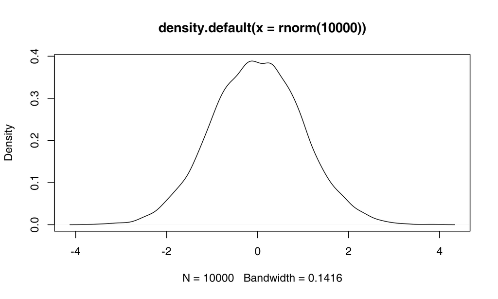

```r
## this is R code inside of a chunk
plot(density(rnorm(10000)))
```

Chunks have several options which determine how the output looks like, what type of graphics is produced (size, resolution) whether you can see the R code etc. etc.

## Using R in markdown for fun and profit

Inline R code:

```
The mtcars data set has `r nrow(mtcars)` rows.
```

Result:

The mtcars data set has 32 rows.

## Using R in markdown for fun and profit

Tables:

```r
library(knitr)
kable(mtcars[1:4, ])
```

|  | mpg | cyl | disp | hp | drat | wt | qsec | vs | am | gear | carb |
| --- | --- | --- | --- | --- | --- | --- | --- | --- | --- | --- | --- |
| Mazda RX4 | 21.0 | 6 | 160 | 110 | 3.90 | 2.620 | 16.46 | 0 | 1 | 4 | 4 |
| Mazda RX4 Wag | 21.0 | 6 | 160 | 110 | 3.90 | 2.875 | 17.02 | 0 | 1 | 4 | 4 |
| Datsun 710 | 22.8 | 4 | 108 | 93 | 3.85 | 2.320 | 18.61 | 1 | 1 | 4 | 1 |
| Hornet 4 Drive | 21.4 | 6 | 258 | 110 | 3.08 | 3.215 | 19.44 | 1 | 0 | 3 | 1 |

## Exercise session 2/5

## More on Rmarkdown

- the YAML header
- adding references
- bookdown

## YAML header

- information about how the document should be rendered
- formatting options
- when you select options from Rstudio, they will modify the YAML header (which is a good thing)
- contains title, author, abstract etc.

## References

- By default, always at the end of the document
- open a new file, call it `bibliography.bib` or similar
- go to Google scholar, search for a paper, click on “BibTeX” and copy the contents to the file
- add a line to the header of the Rmarkdown document:

  ```
  bibliography: "bibliography.bib"
  ```

- insert references like this: `[@weiner2018metabolite]` which generates: (Weiner et al. 2018)

## References: journal style

- go to https://www.zotero.org/styles or https://github.com/citation-style-language/styles
- find your journal and download the csl file (e.g. `nature.csl`). Save it to where your Rmarkdown document is.
- In your YAML header, enter

  ```
  csl: nature.csl
  ```

## Quick exercise

Add a reference to your markdown document

- go to google scholar, find a paper (e.g. the paper of Altschul on BLAST)
- click on “cite.” Then, click on BibTeX. Copy the text and paste it into a document called “bibliography.bib”
- note the citation label in the first line (`altschul1997gapped`)
- save the document where your Rmarkdown document is.
- add the bibliography line to the YAML header
- enter the citation `[@altschul1997gapped]`
- knit the document and enjoy the result

## Bookdown

Bookdown is an extension of Rmarkdown to make writing books easy

- referencing items (figures, equations etc.)
- each chapter is one file
- tons of hacks for specific occasions

## Manuscript writing with Rmarkdown

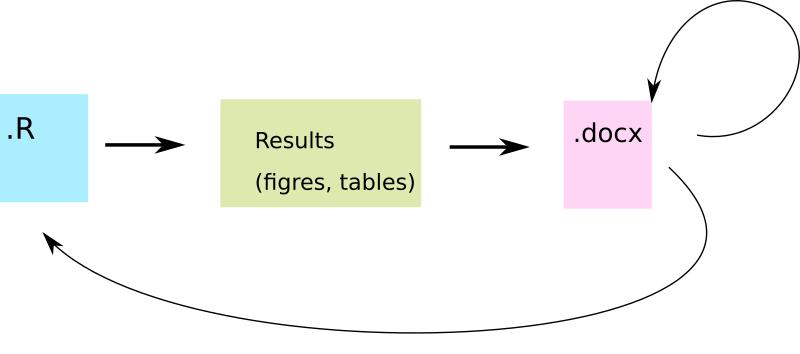

- Advantages: you can easily collaborate with Word collaboration options
- Disadvantages: manually entering output from R results in frequent mistakes; also, it is tedious and boring

## Manuscript writing with Rmarkdown

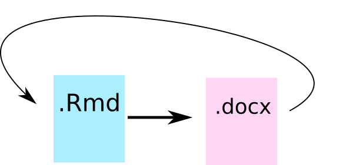

- Disadvantages: hard to collaborate, you need to manually enter all the remarks from your co-authors
- Advantages: easy, automatic updates of the manuscript; no manual editing of figures or tables; no worries about the bibliography; easy to convert a report to a presentation and a paper; easy to quickly see the effects of one small change on your whole manuscript; you can use github for your manuscripts!

## Presentations with Rmarkdown

- Usually produces a HTML which can be viewed in any browser
- Two options are probably best suited for most purposes:
  - `ioslides_presentation` (this one); advantage: a single file
  - `xaringan`: better, nicer, cooler, but multiple files

Weiner, January, Jeroen Maertzdorf, Jayne S Sutherland, Fergal J Duffy, Ethan Thompson, Sara Suliman, Gayle McEwen, et al. 2018. “Metabolite Changes in Blood Predict the Onset of Tuberculosis.” *Nature Communications* 9 (1): 1–12.